# Salary Data Analysis (2020-2023) FINAL PROJECT

AHMAD AMMAR

22nd december 2025

# 1. Introduction

This report analyzes salary data from 2020 to 2023. The analysis includes data cleaning, missing value detection, outlier identification, and descriptive statistics.

# 2. Load Required Libraries

```r
library(tidyverse)
library(readxl)
library(knitr)
library(kableExtra)
```

What this does: This loads the tools (libraries) needed for the analysis. Tidyverse is for data work, readxl reads Excel files, knitr and kableExtra make nice tables.

# 3. Data Import

```r
# Set file paths
data_path <- "C:/Users/HP/Desktop/R FINAL PROJECT/data/"

# Load data from Excel files
Data_2020_xlsx <- read_excel(paste0(data_path, "Data_2020.xlsx"))
Data_2021_xlsx <- read_excel(paste0(data_path, "Data_2021.xlsx"))
Data_2022_xlsx <- read_excel(paste0(data_path, "Data_2022.xlsx"))
Data_2023_xlsx <- read_excel(paste0(data_path, "Data_2023.xlsx"))

# Combine all years
concatenated_data <- rbind(Data_2020_xlsx, Data_2021_xlsx,
                           Data_2022_xlsx, Data_2023_xlsx)

# Display dataset dimensions
cat("Total rows in combined data:", nrow(concatenated_data), "\n")
```

```
## Total rows in combined data: 3761
```

```r
cat("Total columns:", ncol(concatenated_data), "\n")
```

```
## Total columns: 9
```

```r
# View column names
cat("Column Names:\n")
```

```
## Column Names:
```

```r
print(colnames(concatenated_data))
```

```
## [1] "work_year"        "experience_level" "employment_type"  "job_title"
## [5] "salary"           "salary_currency"  "salary_in_usd"    "company_location"
## [9] "company_size"
```

```r
# Data structure
str(concatenated_data)
```

```
## tibble [3,761 × 9] (S3: tbl_df/tbl/data.frame)
##  $ work_year       : num [1:3761] 2020 2020 2020 2020 2020 2020 2020 2020 2020 2020 ...
##  $ experience_level: chr [1:3761] "EN" "EN" "EN" "EN" ...
##  $ employment_type : chr [1:3761] "FT" "FT" "FT" "FT" ...
##  $ job_title       : chr [1:3761] "Data Engineer" "Data Engineer" "Data Analyst" "Data Scientist" ...
##  $ salary          : num [1:3761] 1000000 1000000 20000 43200 48000 70000 250000 10000 138000 14000 ...
##  $ salary_currency : chr [1:3761] "INR" "INR" "EUR" "EUR" ...
##  $ salary_in_usd   : num [1:3761] 13493 13493 22809 49268 54742 ...
##  $ company_location: chr [1:3761] "IN" "IN" "PT" "DE" ...
##  $ company_size    : chr [1:3761] "L" "L" "M" "S" ...
```

```r
# First few rows
head(concatenated_data) %>%
  kable() %>%
  kable_styling(bootstrap_options = c("striped", "hover", "condensed"))
```

| work_year | experience_level | employment_type | job_title | salary | salary_currency | salary_in_usd | company_location | company_size |
| --- | --- | --- | --- | --- | --- | --- | --- | --- |
| 2020 | EN | FT | Data Engineer | 1000000 | INR | 13493 | IN | L |
| 2020 | EN | FT | Data Engineer | 1000000 | INR | 13493 | IN | L |
| 2020 | EN | FT | Data Analyst | 20000 | EUR | 22809 | PT | M |
| 2020 | EN | FT | Data Scientist | 43200 | EUR | 49268 | DE | S |
| 2020 | EN | FT | Data Engineer | 48000 | EUR | 54742 | DE | L |
| 2020 | EN | FT | Big Data Engineer | 70000 | USD | 70000 | US | L |

First, I look at all the column names to see what information I have

Then I use str() (short for “structure”) to see what type of data is in each column. This tells me if a column has numbers, text, dates, etc.

Then I show the first 6 rows of data in a nice table. The table has:

Stripes on alternating rows (easier to read)

Hover effect (when you move mouse over a row, it highlights)

```r
# Calculate missing percentages
missing_percentage <- concatenated_data %>%
  summarise(across(everything(), ~sum(is.na(.)) / n() * 100)) %>%
  pivot_longer(everything(), names_to = "Variable", values_to = "Missing_Percentage")

# Display missing data table
missing_percentage %>%
  arrange(desc(Missing_Percentage)) %>%
  kable(caption = "Missing Data Percentage by Variable", digits = 2) %>%
  kable_styling(bootstrap_options = c("striped", "hover", "condensed"))
```

Missing Data Percentage by Variable

| Variable | Missing_Percentage |
| --- | --- |
| work_year | 0 |
| experience_level | 0 |
| employment_type | 0 |
| job_title | 0 |
| salary | 0 |
| salary_currency | 0 |
| salary_in_usd | 0 |
| company_location | 0 |
| company_size | 0 |

[figure not shown]

```r
# Visualize missing data
ggplot(missing_percentage, aes(x = reorder(Variable, Missing_Percentage),
                               y = Missing_Percentage)) +
  geom_bar(stat = "identity", fill = "steelblue") +
  coord_flip() +
  labs(title = "Missing Data Percentage by Variable",
       x = "Variable",
       y = "Missing Percentage (%)") +
  theme_minimal()
```

I calculate how much data is missing in each column. For example, if “Salary” column has 10 missing values out of 100 rows, that’s 10% missing

I make a table that shows all columns sorted by which has the most missing data (highest percentage at top)

I create a bar chart to visualize the missing data. The chart has:

Blue bars

Flipped coordinates (bars go sideways so column names are easier to read)

```r
# Remove rows with NA values
combined_data_clean <- na.omit(concatenated_data)

cat("Rows before cleaning:", nrow(concatenated_data), "\n")
```

```
## Rows before cleaning: 3761
```

```r
cat("Rows after cleaning:", nrow(combined_data_clean), "\n")
```

```
## Rows after cleaning: 3761
```

```r
cat("Rows removed:", nrow(concatenated_data) - nrow(combined_data_clean), "\n")
```

```
## Rows removed: 0
```

# 7. Outlier Detection

```r
# Function to detect outliers using IQR method
detect_outliers <- function(x) {
  Q1 <- quantile(x, 0.25, na.rm = TRUE)
  Q3 <- quantile(x, 0.75, na.rm = TRUE)
  IQR <- Q3 - Q1
  outliers <- x < (Q1 - 1.5*IQR) | x > (Q3 + 1.5*IQR)
  return(sum(outliers, na.rm = TRUE))
}

# Apply to numerical columns
numerical_cols <- combined_data_clean %>% select(where(is.numeric))
outlier_counts <- sapply(numerical_cols, detect_outliers)

# Display outlier counts
outlier_df <- data.frame(
  Variable = names(outlier_counts),
  Outlier_Count = outlier_counts
)

outlier_df %>%
  arrange(desc(Outlier_Count)) %>%
  kable(caption = "Outlier Counts by Variable") %>%
  kable_styling(bootstrap_options = c("striped", "hover", "condensed"))
```

Outlier Counts by Variable

|  | Variable | Outlier_Count |
| --- | --- | --- |
| salary | salary | 113 |
| work_year | work_year | 76 |
| salary_in_usd | salary_in_usd | 63 |

# 8. Descriptive Statistics

```r
# Five-value summary function
five_value_summary <- function(data) {
  numerical_data <- data %>% select(where(is.numeric))

  summary_table <- data.frame(
    Variable = names(numerical_data),
    Min = sapply(numerical_data, min, na.rm = TRUE),
    Max = sapply(numerical_data, max, na.rm = TRUE),
    Mean = sapply(numerical_data, mean, na.rm = TRUE),
    Median = sapply(numerical_data, median, na.rm = TRUE),
    SD = sapply(numerical_data, sd, na.rm = TRUE)
  )

  return(summary_table)
}

# Generate summary statistics
summary_stats <- five_value_summary(combined_data_clean)

summary_stats %>%
  kable(caption = "Five-Value Summary Statistics", digits = 2) %>%
  kable_styling(bootstrap_options = c("striped", "hover", "condensed"))
```

Five-Value Summary Statistics

|  | Variable | Min | Max | Mean | Median | SD |
| --- | --- | --- | --- | --- | --- | --- |
| work_year | work_year | 2020 | 2023 | 2022.37 | 2022 | 0.69 |
| salary | salary | 6000 | 30400000 | 190599.89 | 137500 | 671145.72 |
| salary_in_usd | salary_in_usd | 5132 | 450000 | 137555.18 | 135000 | 63022.27 |

# 9. Distribution Visualizations

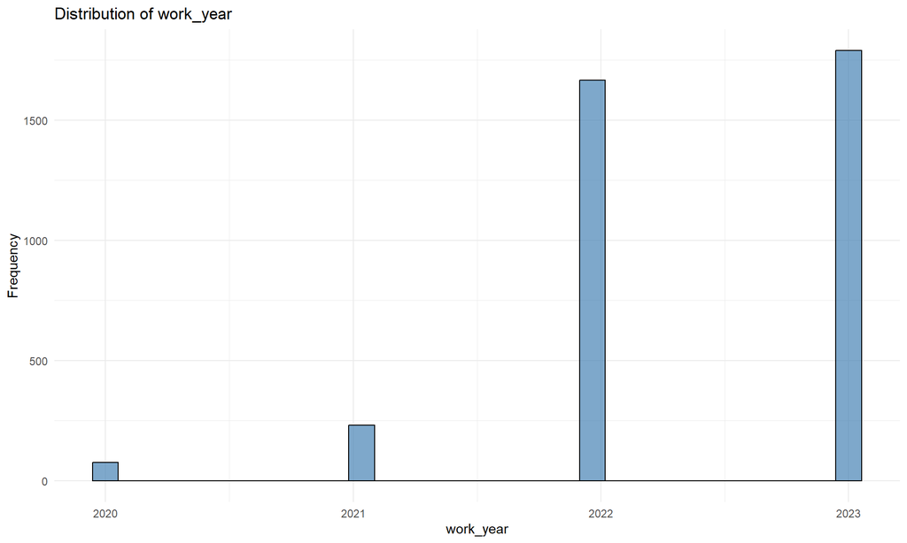

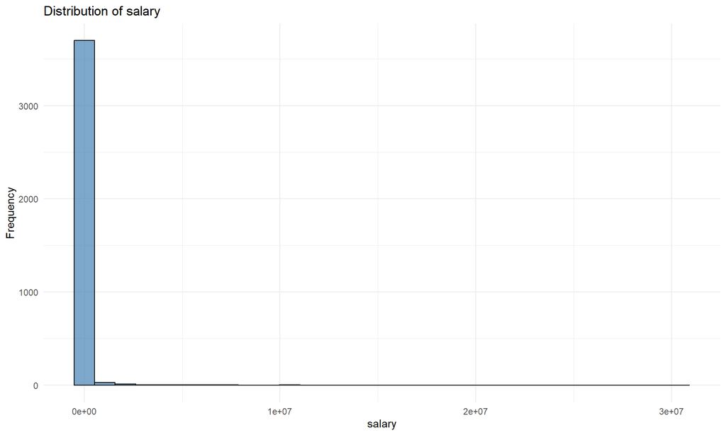

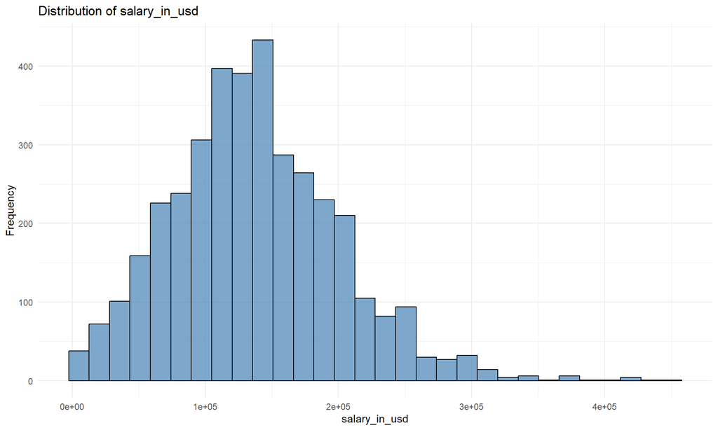

```r
# Create histograms for numerical variables
numerical_data <- combined_data_clean %>% select(where(is.numeric))

for (col in names(numerical_data)) {
  p <- ggplot(combined_data_clean, aes_string(x = col)) +
    geom_histogram(bins = 30, fill = "steelblue", color = "black", alpha = 0.7) +
    labs(title = paste("Distribution of", col),
         x = col,
         y = "Frequency") +
    theme_minimal()
  print(p)
}
```

# 10. Export Cleaned Data

```r
# Save combined dataset
write.csv(concatenated_data, "combined_salaries_data.csv", row.names = FALSE)
write.csv(combined_data_clean, "combined_salaries_data_clean.csv", row.names = FALSE)

cat("Data exported successfully!\n")
```

```
## Data exported successfully!
```

```r
cat("Files saved:\n")
```

```
## Files saved:
```

```r
cat("- combined_salaries_data.csv (original)\n")
```

```
## - combined_salaries_data.csv (original)
```

```r
cat("- combined_salaries_data_clean.csv (cleaned)\n")
```

```
## - combined_salaries_data_clean.csv (cleaned)
```

# 11. Conclusion

This analysis has successfully:

- Loaded and combined salary data from 2020-2023
- Identified missing values and their percentages
- Cleaned the dataset by removing incomplete records
- Detected outliers using the IQR method
- Generated comprehensive descriptive statistics
- Visualized data distributions
- Exported cleaned datasets for further analysis

## Key Findings

- Total records analyzed: 3761
- Clean records after removing NAs: 3761
- Data quality rate: 100%

*Report generated on 2025-12-22*